# Baseball_Cards, Assignment 1b

Jim Albert, Damilare Olaleye

August 21, 2017, August 29, 2019

## Baseball Card Collection Problem

Your instructor used to collect baseball cards which motivates this simulation exercise.

Suppose a set of baseball cards are numbered from 1 to N. You purchase M cards where each card is equally likely to be numbered 1 through N.

What is the chance you buy a complete set?

Set values of N and M:

```r
N <- 30
M <- 150
```

We buy M cards, where each card is equally likely to be 1, …, N. Store the purchases in the vector purchased.

```r
purchased <- sample(N, size=M, replace=TRUE)
purchased
```

```
##   [1] 19 22 13 21  7 29 25  8 17 23 27 20 14 30 27 18 12 12 15 15 29 10  3
##  [24]  2 11 15  1 10 24 19 19 24 26 19 14 28 13 28 17 17  1  3  4  4 17 23
##  [47] 30 16 11 28  2 27  6 20 15 21  8 22  5 24 29 13  6 27  7 11  2 14 17
##  [70] 26 17 19  9 27 19 17 17 28 21  1  5 18 12 21 15  7 18  6 14  7  3 30
##  [93] 11 26 27  1 18  4  5 14 16 14 26  4 27  9 13  8 29 20 23 26  3  8  8
## [116] 10 10 28 25 22 15 19 16 26 30 15 30  8 12 29  5 26 20 25 24  1 20  4
## [139] 12 24 24  8  7 27 10 13 13 30 25 23
```

Graph the numbers of the purchased cards.

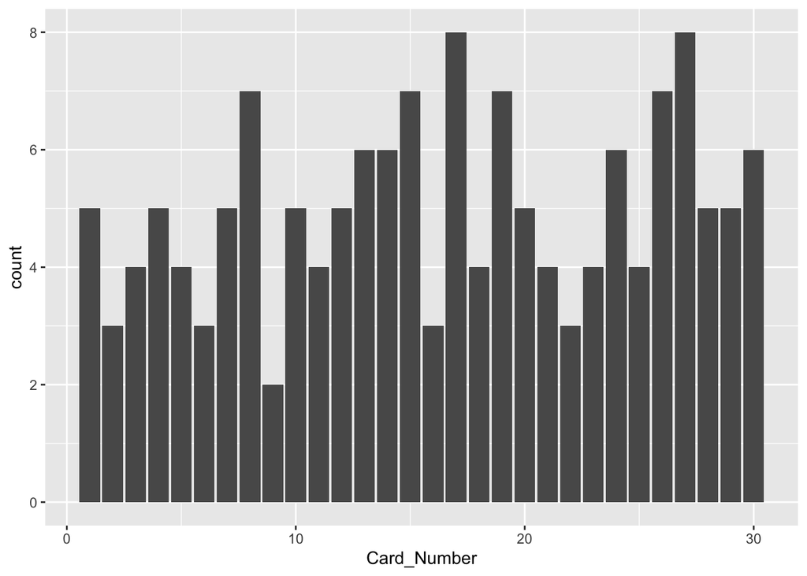

```r
library(ggplot2)
ggplot(data.frame(Card_Number=purchased),
       aes(Card_Number)) +
  geom_bar()
```

We identify the unique cards that are purchased. If the number of unique cards is equal to N, we have a complete set; otherwise the set is not complete.

```r
U <- unique(purchased)
ifelse(length(U) == N, "complete set", "not complete")
```

```
## [1] "complete set"
```

```r
R <- replicate(100, expr = {
  purchased <- sample(N, size=M, replace=TRUE)
  U <- unique(purchased)
  ifelse(length(U) == N, "complete set", "not complete")
})
R
```

```
##   [1] "complete set" "not complete" "not complete" "not complete"
##   [5] "not complete" "complete set" "not complete" "complete set"
##   [9] "complete set" "not complete" "complete set" "complete set"
##  [13] "not complete" "complete set" "complete set" "complete set"
##  [17] "complete set" "complete set" "complete set" "complete set"
##  [21] "complete set" "complete set" "complete set" "not complete"
##  [25] "not complete" "complete set" "complete set" "complete set"
##  [29] "complete set" "complete set" "complete set" "complete set"
##  [33] "complete set" "complete set" "complete set" "complete set"
##  [37] "complete set" "complete set" "complete set" "complete set"
##  [41] "complete set" "complete set" "complete set" "complete set"
##  [45] "complete set" "complete set" "complete set" "complete set"
##  [49] "complete set" "complete set" "complete set" "complete set"
##  [53] "complete set" "complete set" "complete set" "complete set"
##  [57] "complete set" "complete set" "not complete" "complete set"
##  [61] "complete set" "complete set" "not complete" "complete set"
##  [65] "complete set" "complete set" "complete set" "not complete"
##  [69] "complete set" "complete set" "complete set" "complete set"
##  [73] "not complete" "complete set" "complete set" "complete set"
##  [77] "complete set" "complete set" "complete set" "complete set"
##  [81] "not complete" "complete set" "complete set" "not complete"
##  [85] "complete set" "not complete" "complete set" "complete set"
##  [89] "complete set" "complete set" "complete set" "complete set"
##  [93] "complete set" "complete set" "complete set" "complete set"
##  [97] "complete set" "complete set" "complete set" "complete set"
```

I construct a frequency table of the outcomes and graph the data.

```r
(freq <- table(R))
```

```
## R
## complete set not complete
##           84           16
```

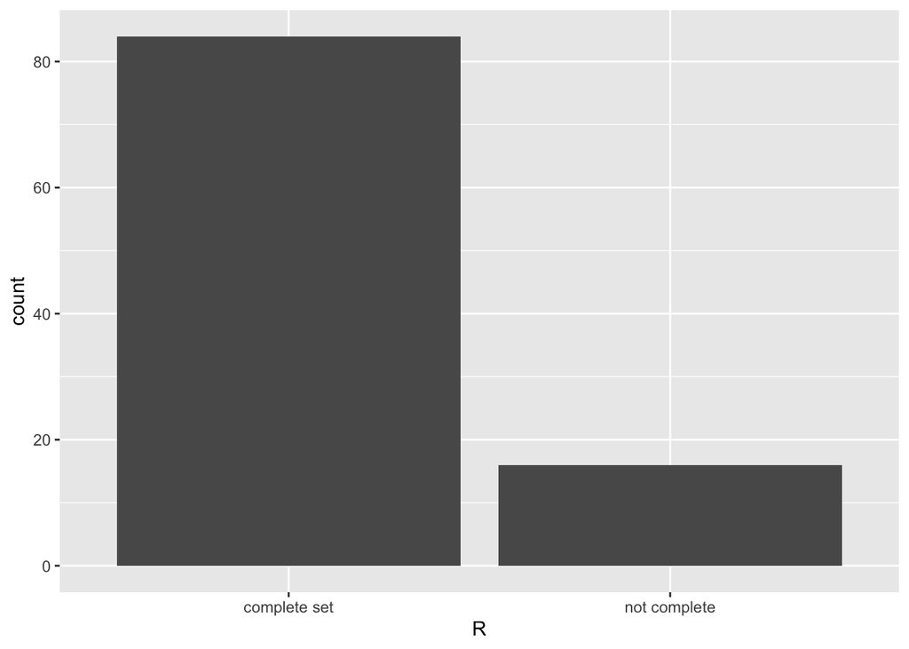

```r
ggplot(data.frame(R), aes(R)) + geom_bar()
```

#### Conclusion

With the values of N and M chosen, it is pretty likely that I have a complete set.